source code can be found [here](https://github.com/capwinters/networkcon)

# A pure geometrical algorithm to determine degree of cell relations in a self optimizing mobile network

Erdem Koç

[figure not shown]

Almost regardless of the radio access technology, one of the most frequently encountered problems in self-optimizing-networks is to define a degree of relation between cells. By relation we mean how much interference does a cell cause on another one, how far is the border between two cells (if any) etc. This is critical in several cases like hand-over, cell-edge performance, interference, overshoot etc.

There are dozens of methods and KPIs to measure and control these relations. However, these methods and kpis almost always need some time to accumulate and if we assume a son algorithm as a "control system with a feedback loop", initial condition is always a point worth looking at.

Even if the control system is already working in closed-loop, one may encounter cases where one has to define purely geographical (or geometrical) rules to handle some exceptions and/or for precaution purposes.

In this notebook I will attempt to define a *purely geometrical algorithm to suggest degree of relation (that includes but not limited to interference) between cells* wrt an origin cell.

Let's start by importing usual libraries and our network library.

> networklib is a list of helper functions to define an interface to a network data that I implemented and described here.

```python
from networklib import networkcon
import pandas as pd
import math
import folium
import matplotlib.pyplot as plt
import geopandas as gpd

%matplotlib notebook
```

and define following two functions to help convert corrdinates to distance and distances to coordinates.

```python
def distance(origin, destination):

    lat1, lon1 = origin
    lat2, lon2 = destination
    radius = 6371  # km

    dlat = math.radians(lat2 - lat1)
    dlon = math.radians(lon2 - lon1)
    a = (math.sin(dlat / 2) * math.sin(dlat / 2) +
         math.cos(math.radians(lat1)) * math.cos(math.radians(lat2)) *
         math.sin(dlon / 2) * math.sin(dlon / 2))
    c = 2 * math.atan2(math.sqrt(a), math.sqrt(1 - a))
    d = radius * c

    return d*1000
```

```python
def latlonscale(lat, lon):
    return (distance((lat+0.5,lon),(lat-0.5,lon)),distance((lat,lon+0.5),(lat,lon-0.5)))
```

Fetch some imaginary network data drom our demo db

```python
nw = networkcon.networkcon("database/network.db")
nw.connect()
```

```
2018-07-07 12:38:00.395096 - C:\Users\tcerdkoc\AppData\Local\Continuum\anaconda3\networklib\networkcon.py - conected to db...
2018-07-07 12:38:00.395096 - C:\Users\tcerdkoc\AppData\Local\Continuum\anaconda3\networklib\networkcon.py - fetching queries from C:\Users\tcerdkoc\AppData\Local\Continuum\anaconda3\networklib\queries
```

```python
network= nw.get_simple("network_query.sql")
network.head()
```

```
2018-07-07 12:38:01.188523 - networkcon - running C:\Users\tcerdkoc\AppData\Local\Continuum\anaconda3\networklib\queries\network_query.sql
```

|  | Cellid | CellName | Siteid | SiteName | Frequency | Power | Azimuth | CellParam1 | CellParam2 | CellParam3 | CellParam4 | CellParam5 | CellParam6 | CellParam7 | CellParam8 | CellParam9 | KPI_x | Longitude | Latitude |
| --- | --- | --- | --- | --- | --- | --- | --- | --- | --- | --- | --- | --- | --- | --- | --- | --- | --- | --- | --- |
| 0 | 5064 | Cell_5064 | 1737 | Site_1737 | Layer1 | 42 | 40 | CB | 206 | 111 | 44 | 56 | 49 | 76 | 34 | 39 | 2.737968 | 13.840828 | 52.555236 |
| 1 | 5065 | Cell_5065 | 1737 | Site_1737 | Layer1 | 42 | 180 | AA | 192 | 230 | 74 | 95 | 93 | 78 | 13 | 52 | 2.737968 | 13.840828 | 52.555236 |
| 2 | 5066 | Cell_5066 | 1737 | Site_1737 | Layer1 | 42 | 320 | BA | 456 | 100 | 22 | 96 | 46 | 15 | 45 | 29 | 2.729109 | 13.840828 | 52.555236 |
| 3 | 5044 | Cell_5044 | 1731 | Site_1731 | Layer2 | 42 | 0 | AA | 228 | 529 | 68 | 51 | 86 | 31 | 25 | 66 | 2.729109 | 13.836542 | 52.495200 |
| 4 | 5045 | Cell_5045 | 1731 | Site_1731 | Layer2 | 42 | 130 | BA | 324 | 323 | 99 | 83 | 69 | 47 | 20 | 38 | 2.729109 | 13.836542 | 52.495200 |

To be able to mathematically define relations between cells, we can use geo-spatial functionality coming from [shapely](https://pypi.org/project/Shapely/). Let's start by plotting our imaginary cells in as *lines in the direction of azimuth*

> Note the visual deformation due to staying in lat, lon axess. We can convert everything in meters for better visualisation, but staying on latitude, longitude dimensions is good enough for this demo and keeps code simpler.

```python
from shapely.geometry import Point, LineString, LinearRing, Polygon
```

```python
def cell2line(lat, lon, azimuth, radius):
    '''Creates a LineString object in thre direction of
    azimuth and length of radius'''

    lat_scale, lon_scale = latlonscale(lat,lon)

    return LineString([(lon, lat)
                    ,(lon + radius*math.cos(azimuth*math.pi/180)/lon_scale
                    ,lat + radius*math.sin(azimuth*math.pi/180)/lat_scale)])
```

Now we use this function to add a geometry type column to network dataframe

```python
radius=3000
plot_radius=200
theta=60
```

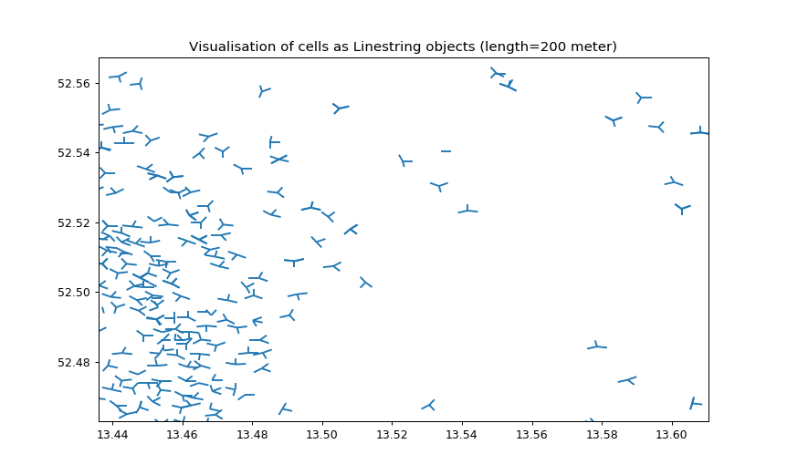

```
Text(0.5,1,'Visualisation of cells as Linestring objects (length=200 meter)')
```

```python
network["toplot"] = network.apply(lambda row: cell2line(row.Latitude, row.Longitude, row.Azimuth, plot_radius), axis=1)

ax=gpd.GeoDataFrame(network, geometry='toplot').plot()
ax.set_title("Visualisation of cells as Linestring objects (length=200 meter)")
```

With similar idea, we create *beams* as Linestring objects. This will become handy to approximate coverge of a cell with a triangle of specific beamwidth.

*Note:*

Following factors are being neglected to keep calculations and code simpler. Extension of everything below should be striaghtforward in a real scenario where better precision is desired.

> Note that this shape can be changed to a ellipse or even a perfect antenna pattern as below. This would increase the complexity of geometrical calculations but depending on the scenario may bring better results

> Note also that we define a fixed length for every beam (vertical pattern), in a real network length of this beam would change depending on the *antenna tilt*.

[figure not shown]

```python
def cell2beam(lat, lon, azimuth, radius, theta):
    '''Creates a LineString object in thre direction of
    azimuth and length of radius with beamwidth of theta'''

    lat_scale, lon_scale = latlonscale(lat,lon)

    return LineString([(lon + radius*math.cos((azimuth-theta/2)*math.pi/180)/lon_scale
                        ,lat + radius*math.sin((azimuth-theta/2)*math.pi/180)/lat_scale),
                        (lon, lat)
                        ,(lon + radius*math.cos((azimuth+theta/2)*math.pi/180)/lon_scale
                        ,lat + radius*math.sin((azimuth+theta/2)*math.pi/180)/lat_scale)])
```

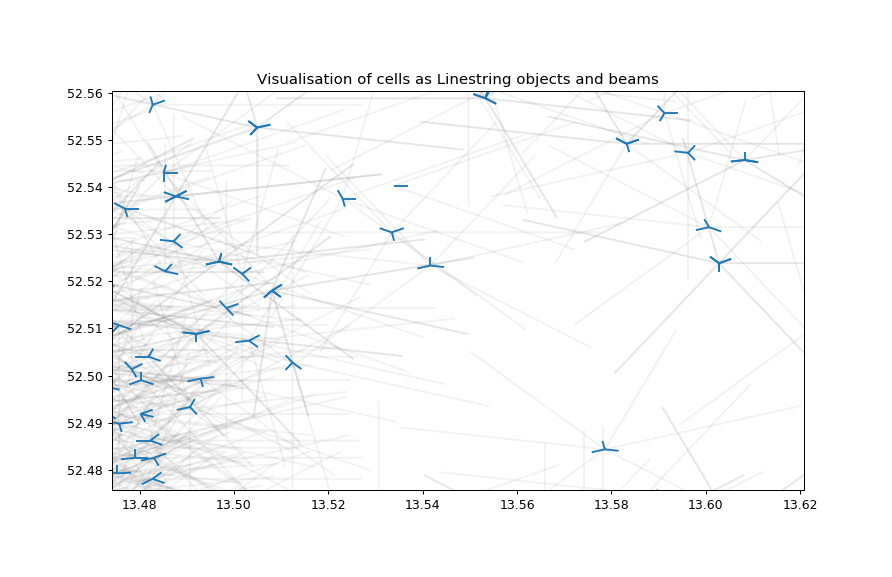

```
Text(0.5,1,'Visualisation of cells as Linestring objects and beams')
```

```python
network["beam"] = network.apply(lambda row: cell2beam(row.Latitude, row.Longitude, row.Azimuth, radius, theta), axis=1)

ax = gpd.GeoDataFrame(network, geometry='beam').plot(color="gray", alpha=0.1)
gpd.GeoDataFrame(network, geometry='toplot').plot(ax=ax)
ax.set_title("Visualisation of cells as Linestring objects and beams")
```

```python
network.head()
```

|  | Cellid | CellName | Siteid | SiteName | Frequency | Power | Azimuth | CellParam1 | CellParam2 | CellParam3 | ... | CellParam5 | CellParam6 | CellParam7 | CellParam8 | CellParam9 | KPI_x | Longitude | Latitude | beam | toplot |
| --- | --- | --- | --- | --- | --- | --- | --- | --- | --- | --- | --- | --- | --- | --- | --- | --- | --- | --- | --- | --- | --- |
| 0 | 5064 | Cell_5064 | 1737 | Site_1737 | Layer1 | 42 | 40 | CB | 206 | 111 | ... | 56 | 49 | 76 | 34 | 39 | 2.737968 | 13.840828 | 52.555236 | LINESTRING (13.88452888875081 52.5599209667401... | LINESTRING (13.840828 52.555236, 13.8430942171... |
| 1 | 5065 | Cell_5065 | 1737 | Site_1737 | Layer1 | 42 | 180 | AA | 192 | 230 | ... | 95 | 93 | 78 | 13 | 52 | 2.737968 | 13.840828 | 52.555236 | LINESTRING (13.80239808338896 52.5687258240887... | LINESTRING (13.840828 52.555236, 13.8378696636... |
| 2 | 5066 | Cell_5066 | 1737 | Site_1737 | Layer1 | 42 | 320 | BA | 456 | 100 | ... | 96 | 46 | 15 | 45 | 29 | 2.729109 | 13.840828 | 52.555236 | LINESTRING (13.85600515938801 52.5298834236961... | LINESTRING (13.840828 52.555236, 13.8430942171... |
| 3 | 5044 | Cell_5044 | 1731 | Site_1731 | Layer2 | 42 | 0 | AA | 228 | 529 | ... | 51 | 86 | 31 | 25 | 66 | 2.729109 | 13.836542 | 52.495200 | LINESTRING (13.87491942603497 52.4817101759112... | LINESTRING (13.836542 52.4952, 13.839496295633... |
| 4 | 5045 | Cell_5045 | 1731 | Site_1731 | Layer2 | 42 | 130 | BA | 324 | 323 | ... | 83 | 69 | 47 | 20 | 38 | 2.729109 | 13.836542 | 52.495200 | LINESTRING (13.82884687920401 52.5217697666988... | LINESTRING (13.836542 52.4952, 13.834643015371... |

5 rows × 21 columns

### Now the most important point:

We will approximate the interfernece of a cell onto another one as the dot product of following vectors:

- v1: a unit vector in the direciton of azimuth
- v2: a unit vector defined from souce site to target site

Since vector product is a scalar, if the reflection of v1 is in the direction of v2, our dot product will be higher and lower if the refection is on other direction.

This means that *we can add results* of two symmetrical dot products to calculate a metric that is proportional to the degree of influence and since we are using unit vectors values will be in range (-2,2)

> I am hesitating to call this interference, because interference is dependent on much more parameters and has a specific meaning in telecommunications industy. Sorry for confsion all the way :\

[figure not shown]

```python
def relativeazimuth(lat1, lon1, az1, lat2, lon2, az2, radius):

    '''calculates 2 dot products for 2 cells and the vectors
    that connect them seperately and adds the results'''

    lat_scale, lon_scale = latlonscale(lat1, lon1)
    hypot = math.hypot((lat2-lat1)*lat_scale, (lon2-lon1)*lon_scale)

    ay1 = (lon2-lon1)*lon_scale/hypot
    ax1 = (lat2-lat1)*lat_scale/hypot

    lat_scale, lon_scale = latlonscale(lat2, lon2)

    ay2 = (lon1-lon2)*lon_scale/math.hypot((lat1-lat2)*lat_scale,(lon1-lon2)*lon_scale)
    ax2 = (lat1-lat2)*lat_scale/math.hypot((lat1-lat2)*lat_scale,(lon1-lon2)*lon_scale)

    x1 = math.sin(az1*math.pi/180)
    y1 = math.cos(az1*math.pi/180)

    x2 = math.sin(az2*math.pi/180)
    y2 = math.cos(az2*math.pi/180)

    # vector dot product and addition leads to values of range (2,2)
    if hypot<2*radius:
        return float((ax1*x1+ay1*y1+ax2*x2+ay2*y2)*(-hypot/(2*radius)+1)+2)
        #return float((ax1*x1+ay1*y1+ax2*x2+ay2*y2)+2)
    else:
        return .0
```

Now, its time to check results.. Let's select a random cell first

```python
from random import randint
origin = gpd.GeoDataFrame(network, geometry='beam').iloc[[randint(0, 1500)]]
origin
```

|  | Cellid | CellName | Siteid | SiteName | Frequency | Power | Azimuth | CellParam1 | CellParam2 | CellParam3 | ... | CellParam5 | CellParam6 | CellParam7 | CellParam8 | CellParam9 | KPI_x | Longitude | Latitude | beam | toplot |
| --- | --- | --- | --- | --- | --- | --- | --- | --- | --- | --- | --- | --- | --- | --- | --- | --- | --- | --- | --- | --- | --- |
| 1090 | 3192 | Cell_3192 | 1060 | Site_1060 | Layer1 | 47 | 130 | CB | 394 | 340 | ... | 34 | 60 | 16 | 31 | 10 | 1.537487 | 13.375333 | 52.500806 | LINESTRING (13.3676368979852 52.5273757666988,... | LINESTRING (13.375333 52.500806, 13.3734337732... |

1 rows × 21 columns

Following is a small extension of cell2beam() funciton, that closes the linestring and creates a shapely polygon. Since I am exploiting geographical funcitons of shapely, having a polygon for source cell only keeps calculations simpler and improves the algorithm while selecting cells that look almost at the same direciton with source cell.

```python
def cell2poly(lat, lon, azimuth, radius, theta):
    '''Creates a LineString object in thre direction of
    azimuth and length of radius with beamwidth of theta'''

    lat_scale, lon_scale = latlonscale(lat,lon)

    return Polygon([(lon + radius*math.cos((azimuth-theta/2)*math.pi/180)/lon_scale
                        ,lat + radius*math.sin((azimuth-theta/2)*math.pi/180)/lat_scale),
                        (lon, lat)
                        ,(lon + radius*math.cos((azimuth+theta/2)*math.pi/180)/lon_scale
                        ,lat + radius*math.sin((azimuth+theta/2)*math.pi/180)/lat_scale)])
```

```python
beam = cell2poly(origin.Latitude, origin.Longitude, origin.Azimuth, radius, theta)
```

Now we will calcuate 2 columns.

*intersects:* that selects cells whose beam intersects with the beam of source cell. This is a rough list of candidates.

*relative:* This applies the dot product algorithm I described above and does the fine tuning

```python
network["intersects"] = network.apply(lambda row: beam.intersects(row["beam"]), axis =1)
```

```python
network["relative"] = network.apply(lambda row: relativeazimuth(origin.Latitude, origin.Longitude, origin.Azimuth,
                                                      row.Latitude, row.Longitude, row.Azimuth, radius), axis =1)
```

Let's see how our relative values are distributed.

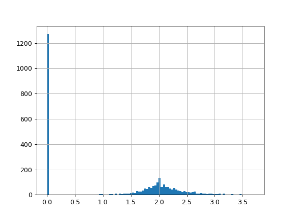

```python
plt.figure()
network.relative.hist(bins=100)
```

That's promising. Let's plot a visualisation to see the algorithm in action

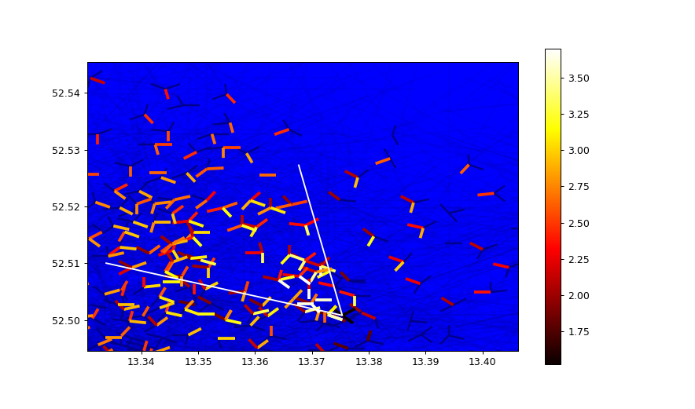

```python
df = gpd.GeoDataFrame(network, geometry='beam')
ax = df.plot(alpha=0.1, color="darkblue")
ax.set_facecolor('b')
df.set_geometry("toplot").plot(ax=ax, color="darkblue", linewidth=2)
df[df["intersects"]].set_geometry("toplot").plot(ax=ax, column="relative",legend =True, cmap="hot", linewidth=3)
gpd.GeoDataFrame(origin, geometry='beam').plot(ax=ax, color="white")
```

The result's are visually satisfying. Note also that 3km is a bit agressive considering the average inter-site distance, hence a lot of cells are in the list.

Now let's plot a bit more cells

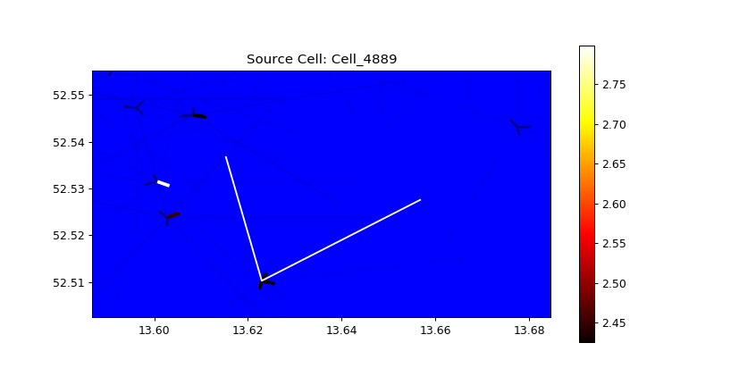

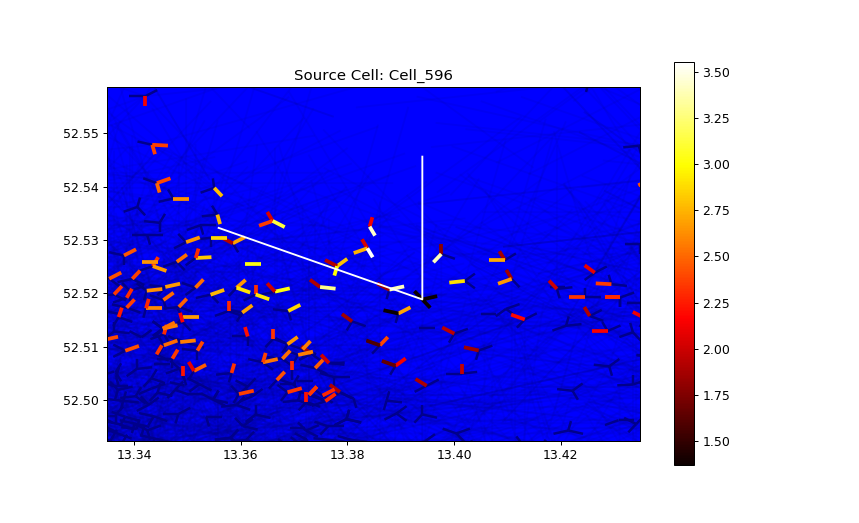

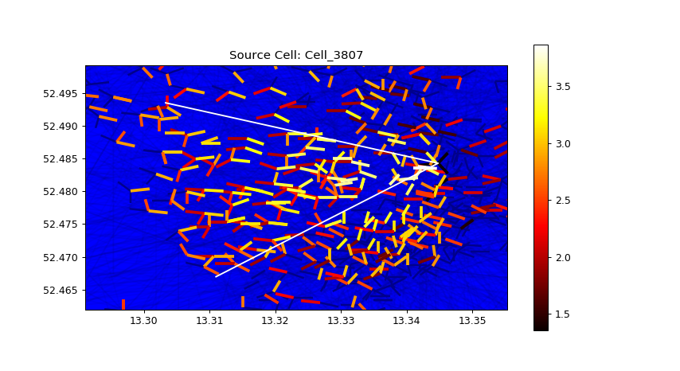

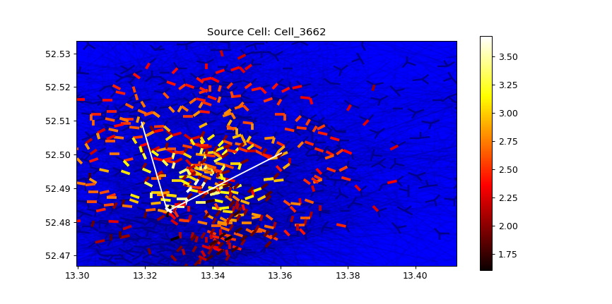

```python
for i in [100,1000,1500, 2000]:
    origin = gpd.GeoDataFrame(network, geometry='beam').iloc[[i]]
    beam = cell2poly(origin.Latitude, origin.Longitude, origin.Azimuth, radius, theta)
    network["intersects"] = network.apply(lambda row: beam.intersects(row["beam"]), axis =1)
    network["relative"] = network.apply(lambda row: relativeazimuth(origin.Latitude, origin.Longitude, origin.Azimuth,
                                                          row.Latitude, row.Longitude, row.Azimuth, radius), axis =1)
    df = gpd.GeoDataFrame(network, geometry='beam')
    ax = df.plot(alpha=0.1, color="darkblue")
    ax.set_facecolor('b')
    df.set_geometry("toplot").plot(ax=ax, color="darkblue", linewidth=2)
    df[df["intersects"]].set_geometry("toplot").plot(ax=ax, column="relative",legend =True, cmap="hot", linewidth=3)
    gpd.GeoDataFrame(origin, geometry='beam').plot(ax=ax, color="white")
    ax.set_title("Source Cell: " + str(origin.iloc[0].CellName))
```